# Ames Housing Dataset Regression Analysis

### Relationships Between Predictors and Sale Price

*Prompt 28 [PYTHON]: Create scatter plots showing the relationship between SalePrice and each of the key predictor variables.*

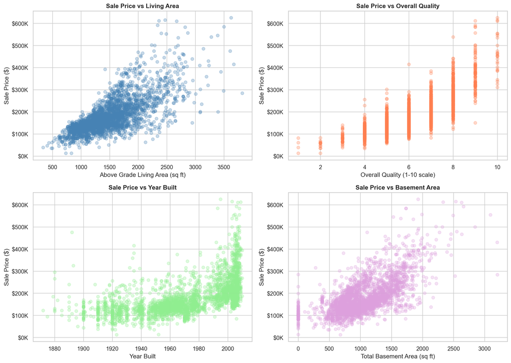

```python
# Create 2x2 subplot for relationships with SalePrice
fig, axes = plt.subplots(2, 2, figsize=(14, 10))

# SalePrice vs GrLivArea
axes[0, 0].scatter(housing['GrLivArea'], housing['SalePrice'],
                   alpha=0.3, color='steelblue')
axes[0, 0].set_xlabel('Above Grade Living Area (sq ft)')
axes[0, 0].set_ylabel('Sale Price ($)')
axes[0, 0].set_title('Sale Price vs Living Area', fontweight='bold')
axes[0, 0].yaxis.set_major_formatter(plt.FuncFormatter(lambda x, p: f'${x/1000:.0f}K'))

# SalePrice vs OverallQual
axes[0, 1].scatter(housing['OverallQual'], housing['SalePrice'],
                   alpha=0.3, color='coral')
axes[0, 1].set_xlabel('Overall Quality (1-10 scale)')
axes[0, 1].set_ylabel('Sale Price ($)')
axes[0, 1].set_title('Sale Price vs Overall Quality', fontweight='bold')
axes[0, 1].yaxis.set_major_formatter(plt.FuncFormatter(lambda x, p: f'${x/1000:.0f}K'))

# SalePrice vs YearBuilt
axes[1, 0].scatter(housing['YearBuilt'], housing['SalePrice'],
                   alpha=0.3, color='lightgreen')
axes[1, 0].set_xlabel('Year Built')
axes[1, 0].set_ylabel('Sale Price ($)')
axes[1, 0].set_title('Sale Price vs Year Built', fontweight='bold')
axes[1, 0].yaxis.set_major_formatter(plt.FuncFormatter(lambda x, p: f'${x/1000:.0f}K'))

# SalePrice vs TotalBsmtSF
axes[1, 1].scatter(housing['TotalBsmtSF'], housing['SalePrice'],
                   alpha=0.3, color='plum')
axes[1, 1].set_xlabel('Total Basement Area (sq ft)')
axes[1, 1].set_ylabel('Sale Price ($)')
axes[1, 1].set_title('Sale Price vs Basement Area', fontweight='bold')
axes[1, 1].yaxis.set_major_formatter(plt.FuncFormatter(lambda x, p: f'${x/1000:.0f}K'))

plt.tight_layout()
plt.show()
```

**Analysis:**

These scatter plots reveal crucial patterns that align with the professor’s observations from last semester:

1. **GrLivArea vs SalePrice (Top Left):** The plot shows a positive linear relationship overall, but as the professor specifically noted, there is a “strong correlation at the low end” - homes with smaller living areas show a tight, predictable relationship with price. As living area increases beyond 2,500-3,000 sq ft, the relationship becomes more variable, with greater price dispersion. This suggests living area is a strong predictor, particularly for typical homes.
2. **OverallQual vs SalePrice (Top Right):** This plot clearly demonstrates the “nonlinear relationship” the professor observed. While there is a general upward trend, the relationship is not a straight line. Homes rated 8-10 in quality command disproportionately higher prices than the linear progression would suggest. This visual confirmation supports the professor’s recommendation to use a log transformation of OverallQual to capture this curved relationship properly.
3. **YearBuilt vs SalePrice (Bottom Left):** This plot exhibits the “heteroscedastic relationship” the professor mentioned - notice how the variance in sale prices increases for newer homes. Older homes (pre-1950) show relatively consistent, lower prices with less spread. Newer homes (post-1990) show much greater price variation, creating a “funnel” or “fan” shape. This heteroscedasticity violates linear regression assumptions and supports the professor’s suggestion to “experiment with a log transformation” of YearBuilt.
4. **TotalBsmtSF vs SalePrice (Bottom Right):** Shows a generally positive linear relationship, though with more scatter than GrLivArea. Homes with no basement (0 sq ft) span a wide price range, while homes with larger basements tend toward higher prices.

These patterns confirm that transformations will be essential: log(SalePrice) for the skewed response, log(OverallQual) for the nonlinear relationship, and possibly log(YearBuilt) for the heteroscedasticity. The professor’s observations from last year’s data are clearly present in this dataset as well.